# The Factors for Prosper Loan Borrower's Interest Rate

## by Jacky Wang

## Investigation Overview

In this investigation, my main focus would be interested in knowing what factors contribute to the decision of borrower's interest rate for Prosper loan applications.

## Dataset Overview

This data set contains 113,937 loans with 81 variables on each loan, including loan amount, borrower rate (or interest rate), current loan status, borrower income, and many others. Twelve promising features are chosen to do the analysis. Outliers were trimmed leaving 56,639 loans in the dataset to having a more generalized outcome.

## Distribution of Interest Rate

The interest rate appears to be similarly normal distribution, which a few spikes on the high ends.

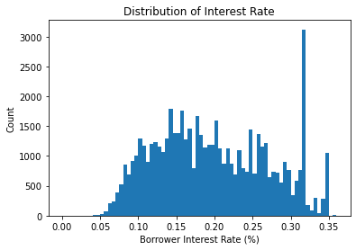

## The Distribution of Credit Score

The credit score is the credit of the borrowers, which was pulled from the credit bureau when loan is applied. I found this to be one of the important factors that has direct impact on the interest rate. The distribution is centered around 650 to 700.

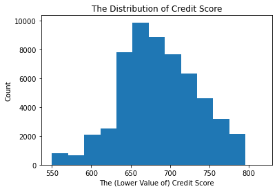

## Interest Rate vs. Borrower's Credit Score

Since interest rate and borrower's credit score are distributed roughly normal, we can plot them using scatter plot to see the trends without any transformations. We can also notice that the credit scores tends to be discrete values.

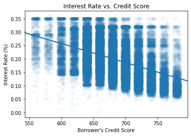

## Interest Rate vs. Categorical Features

I found that all the selected categorical variables - Term, Prosper Score, and Prosper Rate - have impact on the interest rate, and the impact is more consistent than the credit score. Among three of them, the "ProsperRating" appears to have most direct impact on the interst rate.

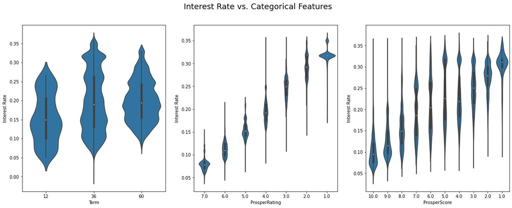

## Interest Rate by Prosper Score and Term

And it is also interesting to see that the interest rate is positive correlated with loan terms when "ProsperScore" is high (from 10 to 7); however after 7, the interest rate is not correlated with the interest rate anymore. We can conclude that when the risk is high, the interest rate is mostly dominated by the risk.

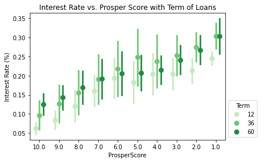

## Interest Rate by Prosper Rating and Term

I also plot the interest rate in terms of two categorical variables "ProsperRating" and "Term". We can see that "ProsperRating" has better control over the inerest rate in terms of the smaller variation it shows. And again, the interest rate consistently increases with Term only up to where the Prosper Rating is 4, after that, they are not much correlated.

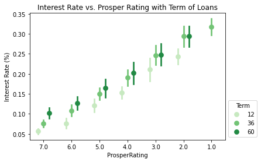